# CS 422 - HW 2

Mark Gameng, Illinois Institute of Technology

## Part 2.1

Question 8 (Gareth James, ISLR 7e)

### (a)

```r
library(ISLR)
fit <- lm(mpg ~ horsepower, data = Auto)
# response ~ predictor
summary(fit)
```

```
Call:
lm(formula = mpg ~ horsepower, data = Auto)

Residuals:
     Min       1Q   Median       3Q      Max
-13.5710  -3.2592  -0.3435   2.7630  16.9240

Coefficients:
             Estimate Std. Error t value Pr(>|t|)
(Intercept) 39.935861   0.717499   55.66   <2e-16 ***
horsepower  -0.157845   0.006446  -24.49   <2e-16 ***
---
Signif. codes:  0 ‘***’ 0.001 ‘**’ 0.01 ‘*’ 0.05 ‘.’ 0.1 ‘ ’ 1

Residual standard error: 4.906 on 390 degrees of freedom
Multiple R-squared:  0.6059,    Adjusted R-squared:  0.6049
F-statistic: 599.7 on 1 and 390 DF,  p-value: < 2.2e-16
```

Yes, there is a relationship between the predictor, horsepower, and the response, mpg. The Pr(>|t|) is really low for the intercept and horsepower, thus it is very unlikely to observe this kind of relationship between the two due to chance. This p value allows us to conclude that there is a relationship between horsepower and mpg.

The relationship between the predictor and the response is fairly strong. It has an R squared value of 0.6059 with an RSE of 4.906. Also the coefficient for horsepower is -0.15784, which is fairly high in my opinion, as +10 horsepower results in about -1.5 mpg.

The relationship is negative, with coefficient of -0.157845. The more horsepower, the less the mpg and vice versa.

```r
predict(fit, newdata = data.frame(horsepower = c(98)),
        interval = "confidence")
```

```
       fit      lwr      upr
1 24.46708 23.97308 24.96108
```

The predicted mpg associated with a horsepower of 98 is 24.46708. The associated 95% confidence interval is (23.97308, 24.96108)

### (b)

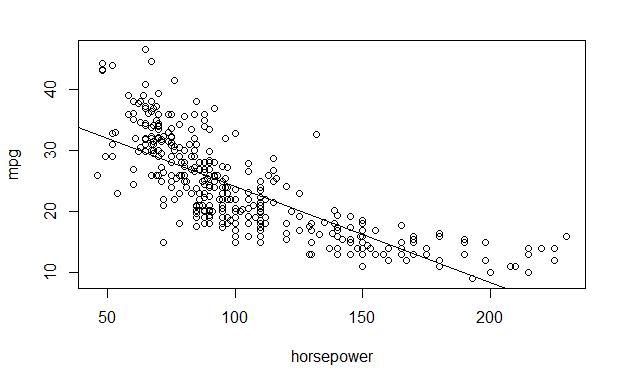

```r
plot(Auto[,c('horsepower', 'mpg')])
abline(lm(mpg ~ horsepower, data = Auto))
```

### (c)

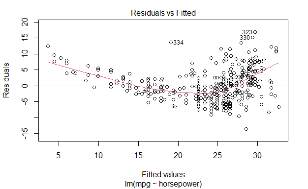

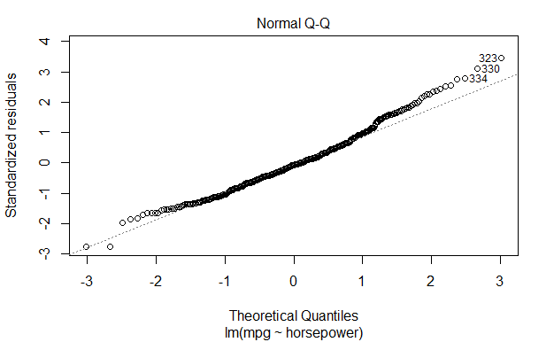

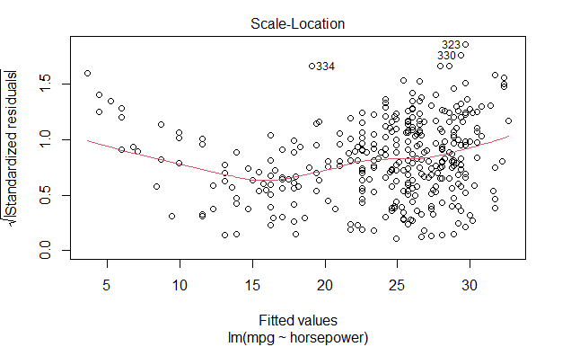

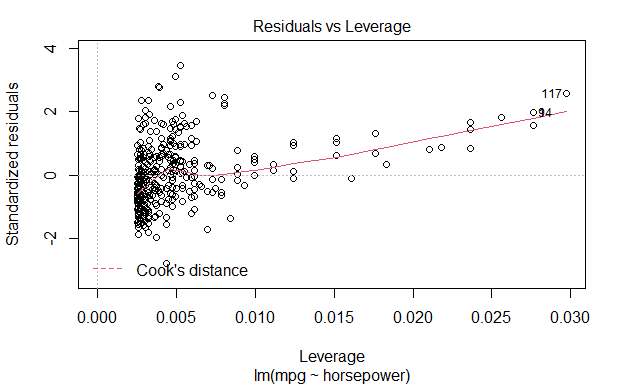

```r
plot(fit)
```

In the residuals vs fitted, the pattern is not linear as after x = 20, the line starts going up. This shows that there might not be a linear relationship between the predictors and response variables. In the Normal Q-Q, residuals are normally distributed, so that’s good. In Scale-Location, the line is not a horizontal line with equally spread points. So, our data does not have uniform variance, or heteroscedastic. The Residuals vs Leverage shows that there are no influential cases.

## Part 2.2

### (a)

```r
set.seed(1122)
index <- sample(1:nrow(Auto), 0.95 * dim(Auto)[1])
train.df <- Auto[index,]
test.df <- Auto[-index,]
Auto.lm <- lm(mpg ~ cylinders + displacement + horsepower + weight + acceleration + origin + year, data = train.df)
```

### (a.i)

Using name as a predictor is not reasonable because its a name, and can have many variations. You can’t really predict mpg just from a name, as similar names could have different variations of a car and thus different mpg.

### (a.ii)

```r
summary(Auto.lm)
```

```
Call:
lm(formula = mpg ~ cylinders + displacement + horsepower + weight +
    acceleration + origin + year, data = train.df)

Residuals:
    Min      1Q  Median      3Q     Max
-9.6805 -2.1786 -0.0977  1.9180 13.0364

Coefficients:
               Estimate Std. Error t value Pr(>|t|)
(Intercept)  -1.660e+01  4.780e+00  -3.472 0.000578 ***
cylinders    -5.235e-01  3.340e-01  -1.567 0.117947
displacement  2.042e-02  7.760e-03   2.632 0.008857 **
horsepower   -1.750e-02  1.424e-02  -1.229 0.219908
weight       -6.416e-03  6.785e-04  -9.457  < 2e-16 ***
acceleration  8.742e-02  1.031e-01   0.848 0.396859
origin        1.516e+00  2.893e-01   5.240 2.73e-07 ***
year          7.383e-01  5.259e-02  14.039  < 2e-16 ***
---
Signif. codes:  0 ‘***’ 0.001 ‘**’ 0.01 ‘*’ 0.05 ‘.’ 0.1 ‘ ’ 1

Residual standard error: 3.367 on 364 degrees of freedom
Multiple R-squared:  0.817, Adjusted R-squared:  0.8135
F-statistic: 232.2 on 7 and 364 DF,  p-value: < 2.2e-16
```

```r
RMSE <- sqrt(c(crossprod(Auto.lm$residuals))/length(Auto.lm$residuals))
print(paste0("RMSE: ", RMSE))
```

```
[1] "RMSE: 3.33051820488739"
```

I would say the model fits the data because the R squared is fairly high with 0.817. R squared is a measure of how well the model fits our data. Also the RSE is fairly low, 3.367, with 364 degrees of freedom. Also the RMSE is 3.33, which is fairly low.

### (a.iii)

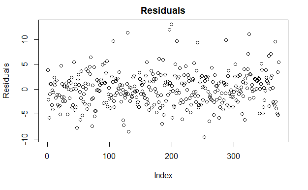

```r
Auto.res <- resid(Auto.lm)
plot(Auto.res, ylab = 'Residuals', main = 'Residuals') # plot residuals
```

### (a.iv)

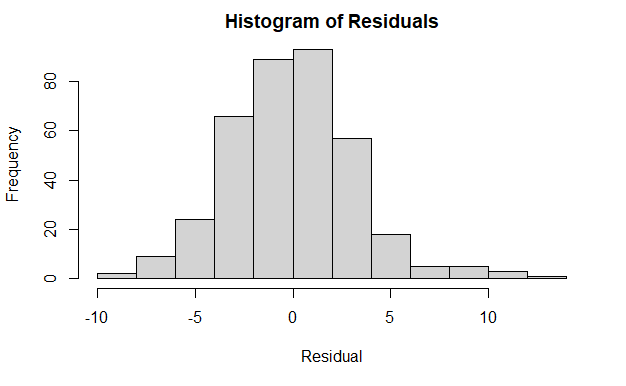

```r
hist(Auto.res, xlab = 'Residual', main = 'Histogram of Residuals')
```

The histogram somewhat follows a Gaussian distribution, but it is a little skewed right. Tends to have a little more negative residuals than positive. Though, they do converge at 0.

### (b.i)

```r
# year, weight, origin are all statistically significant, p is really low
Auto.newlm <- lm(mpg ~ year + weight + origin, data =train.df)
```

### (b.ii)

```r
summary(Auto.newlm)
```

```
Call:
lm(formula = mpg ~ year + weight + origin, data = train.df)

Residuals:
     Min       1Q   Median       3Q      Max
-10.0433  -2.1120  -0.0448   1.6867  13.2596

Coefficients:
              Estimate Std. Error t value Pr(>|t|)
(Intercept) -1.731e+01  4.123e+00  -4.197 3.39e-05 ***
year         7.448e-01  4.983e-02  14.946  < 2e-16 ***
weight      -5.973e-03  2.657e-04 -22.481  < 2e-16 ***
origin       1.223e+00  2.701e-01   4.525 8.15e-06 ***
---
Signif. codes:  0 ‘***’ 0.001 ‘**’ 0.01 ‘*’ 0.05 ‘.’ 0.1 ‘ ’ 1

Residual standard error: 3.389 on 368 degrees of freedom
Multiple R-squared:  0.8126,    Adjusted R-squared:  0.8111
F-statistic: 531.8 on 3 and 368 DF,  p-value: < 2.2e-16
```

```r
RMSE <- sqrt(
  c(crossprod(Auto.newlm$residuals))/length(Auto.newlm$residuals))
print(paste0("RMSE: ", RMSE))
```

```
[1] "RMSE: 3.3708035382656"
```

I would say the model fits the data because the R squared is fairly high with 0.8126. R squared is a measure of how well the model fits our data. Also the RSE is fairly low, 3.389, with 368 degrees of freedom. Also the RMSE is 3.37, which is fairly low.

### (b.iii)

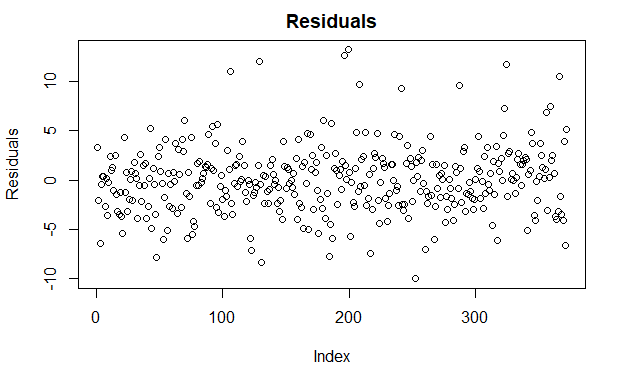

```r
Auto.newres <- resid(Auto.newlm)
plot(Auto.newres, ylab = 'Residuals', main = 'Residuals') # plot residuals
```

### (b.iv)

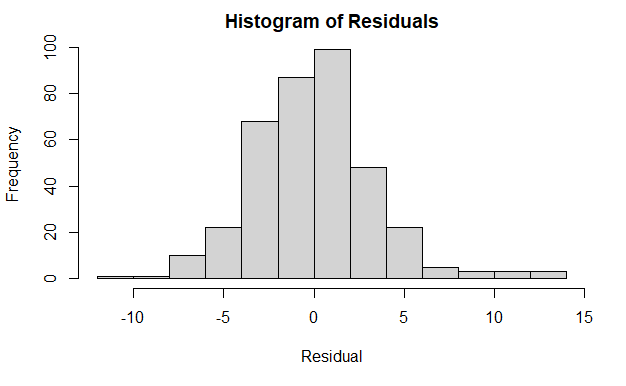

```r
hist(Auto.newres, xlab = 'Residual', main = 'Histogram of Residuals')
```

The histogram does somewhat follow a Gaussian distribution, but it is skewed right. Tends to have more negative residuals than positive.

### (b.v)

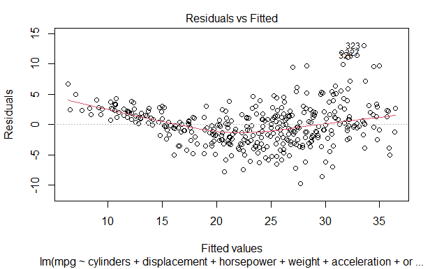

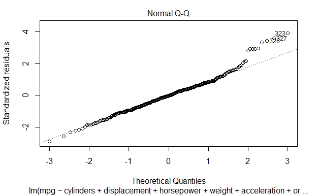

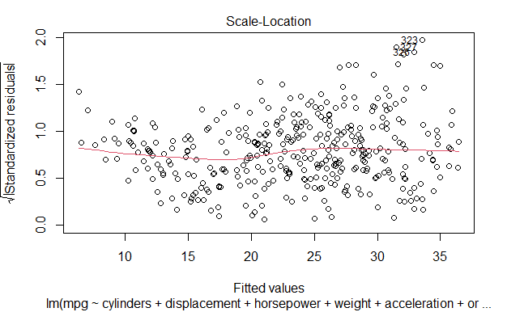

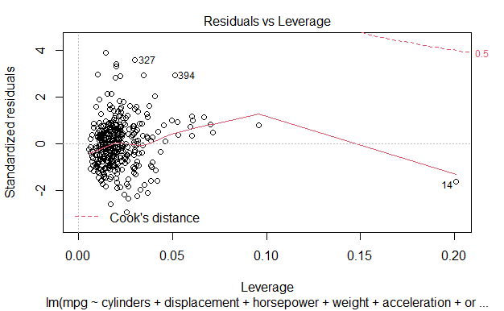

```r
plot(Auto.lm)
```

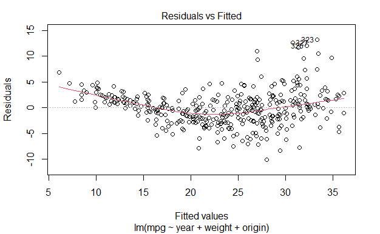

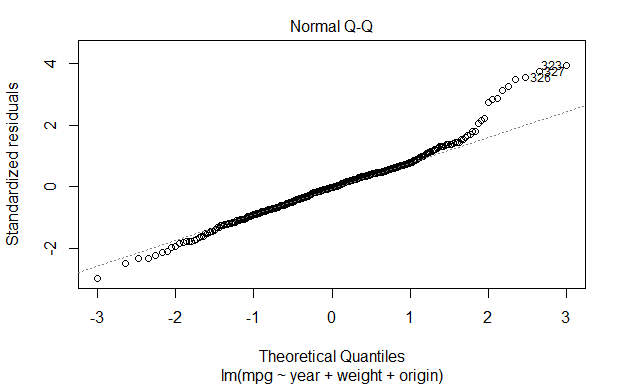

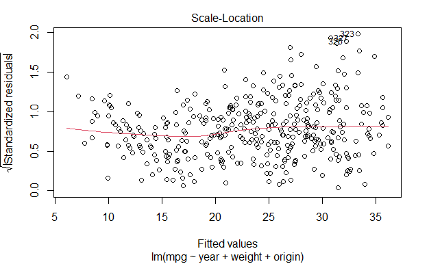

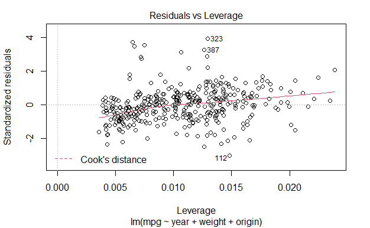

```r
plot(Auto.newlm)
```

I think the model with just the predictors that are statistically significant is better because it is a little better in regards to how the model fits the data, because it only cares about variables that are significant. Also looking at the residual analysis, in the Residual vs Leverage, the model with 3 predictors is much better because there are no influential cases. The other graphs in the residual analysis are similar.

### (c)

```r
pr <- predict(Auto.newlm, test.df, interval = "confidence") # 95% CI
pred.df <- data.frame("Prediction" = pr[,c("fit")],
                      "Response" = test.df[,c("mpg")],
                      "Lower" = pr[,c("lwr")],
                      "Upper" = pr[,c("upr")])
```

### (d)

```r
match_f <- function(r, c1, c2){
  if(c1 <= r && r <= c2){
    return(1)
  }
  return(0)
}
Matches <- apply(pred.df, MARGIN = 1, function(x) match_f(x[2], x[3], x[4]))
pred.df <- cbind(pred.df, Matches)
pred.df
```

|  | Prediction | Response | Lower | Upper | Matches |
| --- | --- | --- | --- | --- | --- |
| 23 | 23.087261 | 25.0 | 22.298650 | 23.87587 | 0 |
| 86 | 13.796155 | 13.0 | 13.202787 | 14.38952 | 0 |
| 96 | 8.713373 | 12.0 | 7.789197 | 9.63755 | 0 |
| 111 | 26.520256 | 22.0 | 25.711209 | 27.32930 | 0 |
| 121 | 22.377070 | 19.0 | 21.874010 | 22.88013 | 0 |
| 140 | 11.327620 | 14.0 | 10.541322 | 12.11392 | 0 |
| 153 | 20.278919 | 19.0 | 19.850586 | 20.70725 | 0 |
| 161 | 16.438462 | 17.0 | 15.923494 | 16.95343 | 0 |
| 176 | 29.427242 | 29.0 | 28.827257 | 30.02723 | 1 |
| 178 | 24.905895 | 23.0 | 24.492442 | 25.31935 | 0 |

[output cut: 10 more lines]

```r
correct <- sum(pred.df[,c("Matches")])
print(paste0("Total observations correctly predicted: ", correct))
```

```
[1] "Total observations correctly predicted: 7"
```

### (e)

```r
prnew <- predict(Auto.newlm, test.df, interval = "prediction") # 95% CI
newpred.df <- data.frame("Prediction" = prnew[,c("fit")],
                      "Response" = test.df[,c("mpg")],
                      "Lower" = prnew[,c("lwr")],
                      "Upper" = prnew[,c("upr")])
Matches <- apply(newpred.df, MARGIN = 1, function(x) match_f(x[2], x[3], x[4]))
newpred.df <- cbind(newpred.df, Matches)
newpred.df
```

|  | Prediction | Response | Lower | Upper | Matches |
| --- | --- | --- | --- | --- | --- |
| 23 | 23.087261 | 25.0 | 16.376384 | 29.79814 | 1 |
| 86 | 13.796155 | 13.0 | 7.105412 | 20.48690 | 1 |
| 96 | 8.713373 | 12.0 | 1.985219 | 15.44153 | 1 |
| 111 | 26.520256 | 22.0 | 19.806946 | 33.23357 | 1 |
| 121 | 22.377070 | 19.0 | 15.693730 | 29.06041 | 1 |
| 140 | 11.327620 | 14.0 | 4.617014 | 18.03823 | 1 |
| 153 | 20.278919 | 19.0 | 13.600788 | 26.95705 | 1 |
| 161 | 16.438462 | 17.0 | 9.754215 | 23.12271 | 1 |
| 176 | 29.427242 | 29.0 | 22.735908 | 36.11858 | 1 |
| 178 | 24.905895 | 23.0 | 18.228702 | 31.58309 | 1 |

[output cut: 10 more lines]

```r
correct <- sum(newpred.df[, c("Matches")])
print(paste0("Total observations correctly predicted: ", correct))
```

```
[1] "Total observations correctly predicted: 20"
```

### (f)

(e), prediction interval, results in more matches. Confidence interval results in 7 matches while prediction interval results in 20 matches.

Prediction interval results in more matches because its confidence interval is much wider. Looking at the first row of the data frames, the range is (22.29,23.87) vs (16.37,29.79). The prediction values are the same for both, the only difference is the lower and upper bound where prediction interval have a much wider range than the confidence interval.